# Homework #6

Natalia Aristizábal

10/3/2018

##### Long and wide data formats

Convert the iris data set into the long format, with a column called “trait” to indicate sepal and petal length and width.

Once you have converted to the long format, calculate the average for each combination of species and trait.

```r
library(dplyr)
library(tibble)
library(tidyr)

data(iris)
head(iris)
```

```
##   Sepal.Length Sepal.Width Petal.Length Petal.Width Species
## 1          5.1         3.5          1.4         0.2  setosa
## 2          4.9         3.0          1.4         0.2  setosa
## 3          4.7         3.2          1.3         0.2  setosa
## 4          4.6         3.1          1.5         0.2  setosa
## 5          5.0         3.6          1.4         0.2  setosa
## 6          5.4         3.9          1.7         0.4  setosa
```

```r
glimpse(iris)
```

```
## Observations: 150
## Variables: 5
## $ Sepal.Length <dbl> 5.1, 4.9, 4.7, 4.6, 5.0, 5.4, 4.6, 5.0, 4.4, 4.9,...
## $ Sepal.Width  <dbl> 3.5, 3.0, 3.2, 3.1, 3.6, 3.9, 3.4, 3.4, 2.9, 3.1,...
## $ Petal.Length <dbl> 1.4, 1.4, 1.3, 1.5, 1.4, 1.7, 1.4, 1.5, 1.4, 1.5,...
## $ Petal.Width  <dbl> 0.2, 0.2, 0.2, 0.2, 0.2, 0.4, 0.3, 0.2, 0.2, 0.1,...
## $ Species      <fct> setosa, setosa, setosa, setosa, setosa, setosa, s...
```

```r
longDat <- iris %>%
  gather(Sepal.Length:Petal.Width, key= "trait", value="Response")

head(longDat)
```

```
##   Species        trait Response
## 1  setosa Sepal.Length      5.1
## 2  setosa Sepal.Length      4.9
## 3  setosa Sepal.Length      4.7
## 4  setosa Sepal.Length      4.6
## 5  setosa Sepal.Length      5.0
## 6  setosa Sepal.Length      5.4
```

```r
longDat %>%
  group_by(Species, trait) %>%
  summarize(AvgResponse=mean(Response)) %>%
  arrange(Species, trait)
```

```
## # A tibble: 12 x 3
## # Groups:   Species [3]
##    Species    trait        AvgResponse
##    <fct>      <chr>              <dbl>
##  1 setosa     Petal.Length       1.46
##  2 setosa     Petal.Width        0.246
##  3 setosa     Sepal.Length       5.01
##  4 setosa     Sepal.Width        3.43
##  5 versicolor Petal.Length       4.26
##  6 versicolor Petal.Width        1.33
##  7 versicolor Sepal.Length       5.94
##  8 versicolor Sepal.Width        2.77
##  9 virginica  Petal.Length       5.55
## 10 virginica  Petal.Width        2.03
## 11 virginica  Sepal.Length       6.59
## 12 virginica  Sepal.Width        2.97
```

#### Simulating and Fitting Data Distributions

This exercise teaches you how to compare a histogram of continuous (or integer) data to the probability density functions for different statistical distributions.

#### Open libraries

```r
library(ggplot2) # for graphics
library(MASS) # for maximum likelihood estimation
```

#### Read in data vector

To illustrate, we will generate some fake data here:

```r
# Nick's data, a truncated normal distribution to work on the solution set
# z <- rnorm(n=3000,mean=0.2)
# z <- data.frame(1:3000,z)
# names(z) <- list("ID","myVar")
# z <- z[z$myVar>0,]
# str(z)
# summary(z$myVar)
```

```r
# read my own data

zNA <- read.table("data_eficiencia_v3.csv", header=TRUE,sep=",", stringsAsFactors=FALSE)
head(zNA)
```

```
##   Landscape ForestCover Point Forest300 Dist coffee300 Branch
## 1        P9       13.59    10     16.96 46.1      52.1      T
## 2        P9       13.59    10     16.96 46.1      52.1      T
## 3        P9       13.59    10     16.96 46.1      52.1      T
## 4        P9       13.59    10     16.96 46.1      52.1      T
## 5        P9       13.59    10     16.96 46.1      52.1      T
## 6        P9       13.59    10     16.96 46.1      52.1      T
##   BranchReplicate TotalFruits CBB Sub_Fruto Bean BeanSize BeanDamage
## 1              T2          26   4         1    a        6          6
## 2              T2          26   4         1    b        6          6
## 3              T2          26   4         2    a        9          9
## 4              T2          26   4         2    b        9          9
## 5              T2          26   4         3    a        9          9
## 6              T2          26   4         3    b        9          9
##   BeanDamage_Percentage Adults Brood       id
## 1                   100      1     0 P9_10_T2
## 2                   100      0     0 P9_10_T2
## 3                   100      7     1 P9_10_T2
## 4                   100      0     0 P9_10_T2
## 5                   100      1     0 P9_10_T2
## 6                   100      0     0 P9_10_T2
```

```r
# clean up data
z <- zNA[complete.cases(zNA),]
head(z)
```

```
##   Landscape ForestCover Point Forest300 Dist coffee300 Branch
## 1        P9       13.59    10     16.96 46.1      52.1      T
## 2        P9       13.59    10     16.96 46.1      52.1      T
## 3        P9       13.59    10     16.96 46.1      52.1      T
## 4        P9       13.59    10     16.96 46.1      52.1      T
## 5        P9       13.59    10     16.96 46.1      52.1      T
## 6        P9       13.59    10     16.96 46.1      52.1      T
##   BranchReplicate TotalFruits CBB Sub_Fruto Bean BeanSize BeanDamage
## 1              T2          26   4         1    a        6          6
## 2              T2          26   4         1    b        6          6
## 3              T2          26   4         2    a        9          9
## 4              T2          26   4         2    b        9          9
## 5              T2          26   4         3    a        9          9
## 6              T2          26   4         3    b        9          9
##   BeanDamage_Percentage Adults Brood       id
## 1                   100      1     0 P9_10_T2
## 2                   100      0     0 P9_10_T2
## 3                   100      7     1 P9_10_T2
## 4                   100      0     0 P9_10_T2
## 5                   100      1     0 P9_10_T2
## 6                   100      0     0 P9_10_T2
```

```r
summary(z)
```

```
##   Landscape          ForestCover        Point         Forest300
##  Length:2077        Min.   :13.59   Min.   :10.00   Min.   : 0.00
##  Class :character   1st Qu.:23.19   1st Qu.:10.00   1st Qu.:12.31
##  Mode  :character   Median :29.00   Median :30.00   Median :16.96
##                     Mean   :29.58   Mean   :31.03   Mean   :26.70
##                     3rd Qu.:30.00   3rd Qu.:60.00   3rd Qu.:45.08
##                     Max.   :55.00   Max.   :60.00   Max.   :60.25
##       Dist          coffee300        Branch          BranchReplicate
##  Min.   :  3.00   Min.   : 8.27   Length:2077        Length:2077
##  1st Qu.: 18.03   1st Qu.:29.72   Class :character   Class :character
##  Median : 25.00   Median :49.73   Mode  :character   Mode  :character
##  Mean   : 32.69   Mean   :48.76
##  3rd Qu.: 36.06   3rd Qu.:72.00
##  Max.   :105.48   Max.   :76.49
##   TotalFruits          CBB          Sub_Fruto         Bean
##  Min.   :  3.00   Min.   : 1.00   Min.   : 1.00   Length:2077
##  1st Qu.: 25.00   1st Qu.: 4.00   1st Qu.: 2.00   Class :character
##  Median : 36.00   Median : 9.00   Median : 4.00   Mode  :character
##  Mean   : 39.39   Mean   :10.08   Mean   : 5.31
##  3rd Qu.: 51.00   3rd Qu.:15.00   3rd Qu.: 7.00
##  Max.   :136.00   Max.   :28.00   Max.   :28.00
##     BeanSize        BeanDamage     BeanDamage_Percentage     Adults
##  Min.   : 5.000   Min.   : 0.000   Min.   :  0.00        Min.   : 0.0000
##  1st Qu.: 9.000   1st Qu.: 0.000   1st Qu.:  0.00        1st Qu.: 0.0000
##  Median :10.000   Median : 4.000   Median : 36.36        Median : 0.0000
##  Mean   : 9.688   Mean   : 4.465   Mean   : 46.67        Mean   : 0.7626
##  3rd Qu.:10.000   3rd Qu.: 9.000   3rd Qu.:100.00        3rd Qu.: 1.0000
##  Max.   :13.000   Max.   :13.000   Max.   :100.00        Max.   :21.0000
##      Brood             id
##  Min.   :0.0000   Length:2077
##  1st Qu.:0.0000   Class :character
##  Median :0.0000   Mode  :character
##  Mean   :0.1632
##  3rd Qu.:0.0000
##  Max.   :8.0000
```

```r
str(z)
```

```
## 'data.frame':    2077 obs. of  18 variables:
##  $ Landscape            : chr  "P9" "P9" "P9" "P9" ...
##  $ ForestCover          : num  13.6 13.6 13.6 13.6 13.6 ...
##  $ Point                : int  10 10 10 10 10 10 10 10 10 10 ...
##  $ Forest300            : num  17 17 17 17 17 ...
##  $ Dist                 : num  46.1 46.1 46.1 46.1 46.1 46.1 46.1 46.1 46.1 46.1 ...
##  $ coffee300            : num  52.1 52.1 52.1 52.1 52.1 52.1 52.1 52.1 52.1 52.1 ...
##  $ Branch               : chr  "T" "T" "T" "T" ...
##  $ BranchReplicate      : chr  "T2" "T2" "T2" "T2" ...
##  $ TotalFruits          : int  26 26 26 26 26 26 26 26 17 17 ...
##  $ CBB                  : int  4 4 4 4 4 4 4 4 3 3 ...
##  $ Sub_Fruto            : int  1 1 2 2 3 3 4 4 1 1 ...
##  $ Bean                 : chr  "a" "b" "a" "b" ...
##  $ BeanSize             : num  6 6 9 9 9 9 11 11 8 8 ...
##  $ BeanDamage           : int  6 6 9 9 9 9 11 11 8 8 ...
##  $ BeanDamage_Percentage: num  100 100 100 100 100 100 100 100 100 100 ...
##  $ Adults               : int  1 0 7 0 1 0 10 0 0 0 ...
##  $ Brood                : int  0 0 1 0 0 0 0 0 0 0 ...
##  $ id                   : chr  "P9_10_T2" "P9_10_T2" "P9_10_T2" "P9_10_T2" ...
```

#### Plot histogram of data

Plot a histogram of the data, using a modification of the code from lecture. Here we are switching from qplot to ggplot for more graphics options. We are also rescaling the y axis of the histogram from counts to density, so that the area under the histogram equals 1.0.

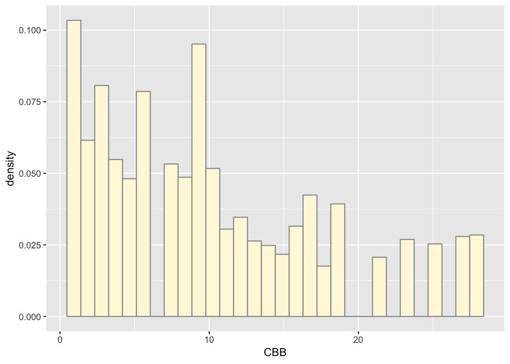

```r
p1 <- ggplot(data=z, aes(x=CBB, y=..density..)) +
  geom_histogram(color="grey60",fill="cornsilk",size=0.5)
print(p1)
```

#### Add empirical density curve

Now modify the code to add in a kernel density plot of the data. This is an empirical curve that is fitted to the data. It does not assume any particular probability distribution, but it smooths out the shape of the histogram:

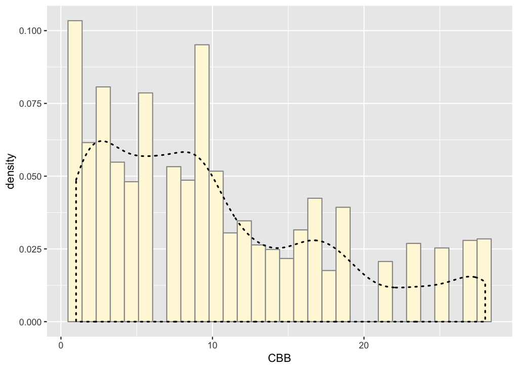

```r
p1 <-  p1 +  geom_density(linetype="dotted",size=0.75)
print(p1)
```

#### Get maximum likelihood parameters for normal

Next, fit a normal distribution to your data and grab the maximum likelihood estimators of the two parameters of the normal, the mean and the variance:

```r
normPars <- fitdistr(z$CBB,"normal")
print(normPars)
```

```
##       mean          sd
##   10.0813674    7.4969180
##  ( 0.1644995) ( 0.1163187)
```

```r
str(normPars)
```

```
## List of 5
##  $ estimate: Named num [1:2] 10.1 7.5
##   ..- attr(*, "names")= chr [1:2] "mean" "sd"
##  $ sd      : Named num [1:2] 0.164 0.116
##   ..- attr(*, "names")= chr [1:2] "mean" "sd"
##  $ vcov    : num [1:2, 1:2] 0.0271 0 0 0.0135
##   ..- attr(*, "dimnames")=List of 2
##   .. ..$ : chr [1:2] "mean" "sd"
##   .. ..$ : chr [1:2] "mean" "sd"
##  $ n       : int 2077
##  $ loglik  : num -7131
##  - attr(*, "class")= chr "fitdistr"
```

```r
normPars$estimate["mean"] # note structure of getting a named attribute
```

```
##     mean
## 10.08137
```

#### Plot normal probability density

Now let’s call the dnorm function inside ggplot’s stat_function to generate the probability density for the normal distribution. Read about stat_function in the help system to see how you can use this to add a smooth function to any ggplot. Note that we first get the maximum likelihood parameters for a normal distribution fitted to thse data by calling fitdistr. Then we pass those parameters (meanML and sdML to stat_function:

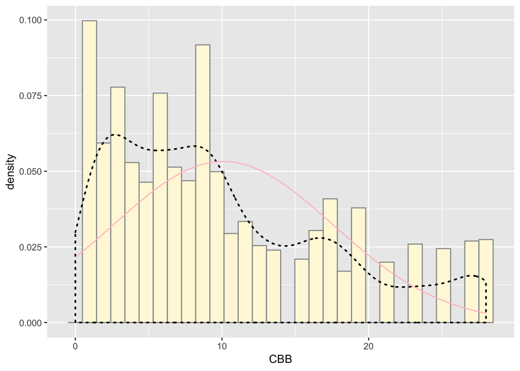

```r
meanML <- normPars$estimate["mean"]
sdML <- normPars$estimate["sd"]

xval <- seq(0,max(z$CBB),len=length(z$CBB))

stat <- stat_function(aes(x = xval, y = ..y..), fun = dnorm, colour="pink", n = length(z$CBB), args = list(mean = meanML, sd = sdML))
p1 + stat
```

#### Plot exponential probability density

Now let’s use the same template and add in the curve for the exponential:

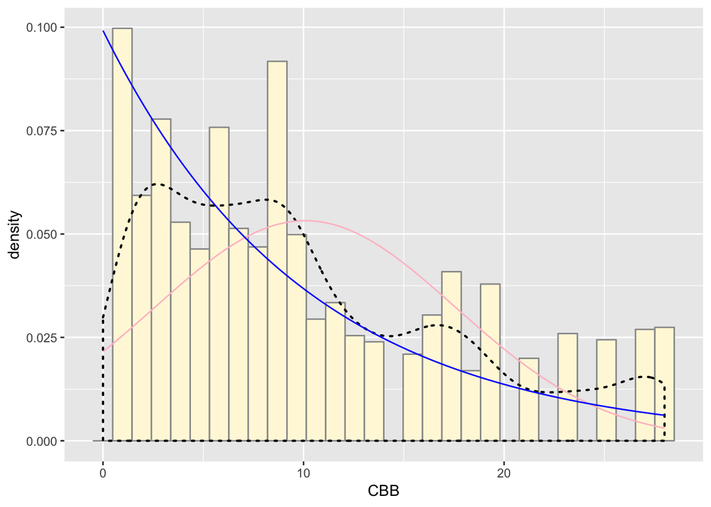

```r
expoPars <- fitdistr(z$CBB,"exponential")
rateML <- expoPars$estimate["rate"]

stat2 <- stat_function(aes(x = CBB, y = ..y..), fun = dexp, colour="blue", n = length(z$CBB), args = list(rate=rateML))
p1 + stat + stat2
```

#### Plot uniform probability density

For the uniform, we don’t need to use fitdistr because the maximum likelihood estimators of the two parameters are just the minimum and the maximum of the data:

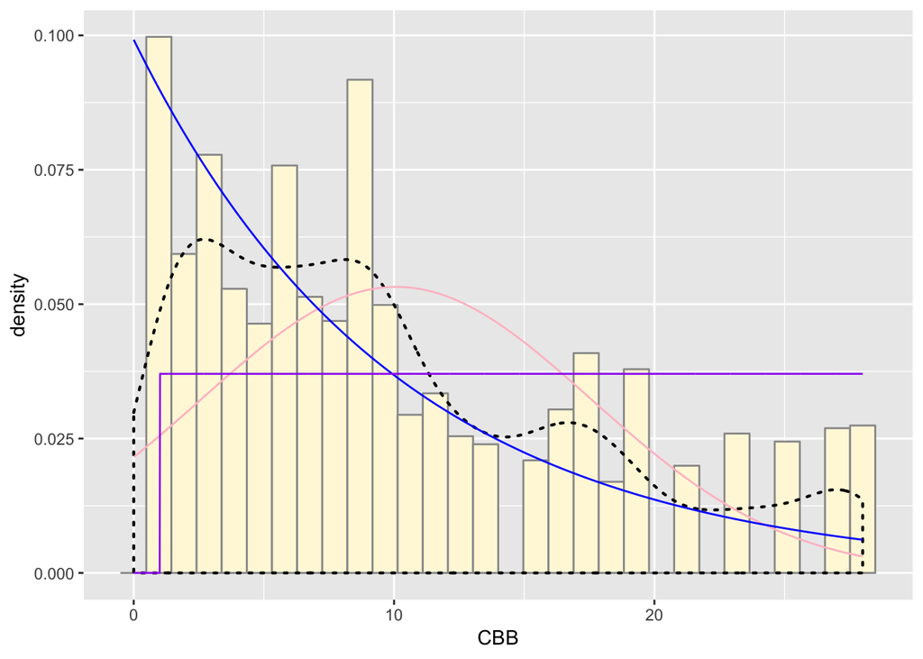

```r
stat3 <- stat_function(aes(x = CBB, y = ..y..), fun = dunif, colour="purple", n = length(z$CBB), args = list(min=min(z$CBB), max=max(z$CBB)))
p1 + stat + stat2 + stat3
```

#### Plot gamma probability density

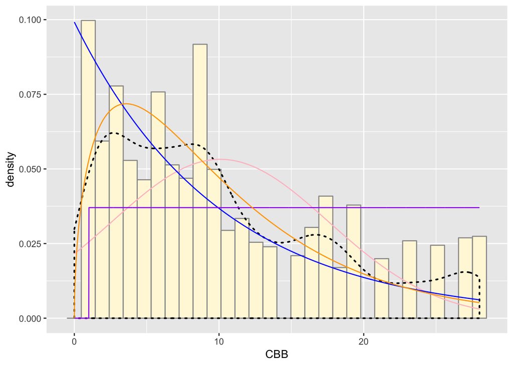

```r
gammaPars <- fitdistr(z$CBB,"gamma")
shapeML <- gammaPars$estimate["shape"]
rateML <- gammaPars$estimate["rate"]

stat4 <- stat_function(aes(x = xval, y = ..y..), fun = dgamma, colour="orange", n = length(z$CBB), args = list(shape=shapeML, rate=rateML))
p1 + stat + stat2 + stat3 + stat4
```

```r
# gamma is really the distribution to best fit my data.
```

#### Plot beta probability density

This one has to be shown in its own plot because the raw data must be rescaled so they are between 0 and 1, and then they can be compared to the beta.

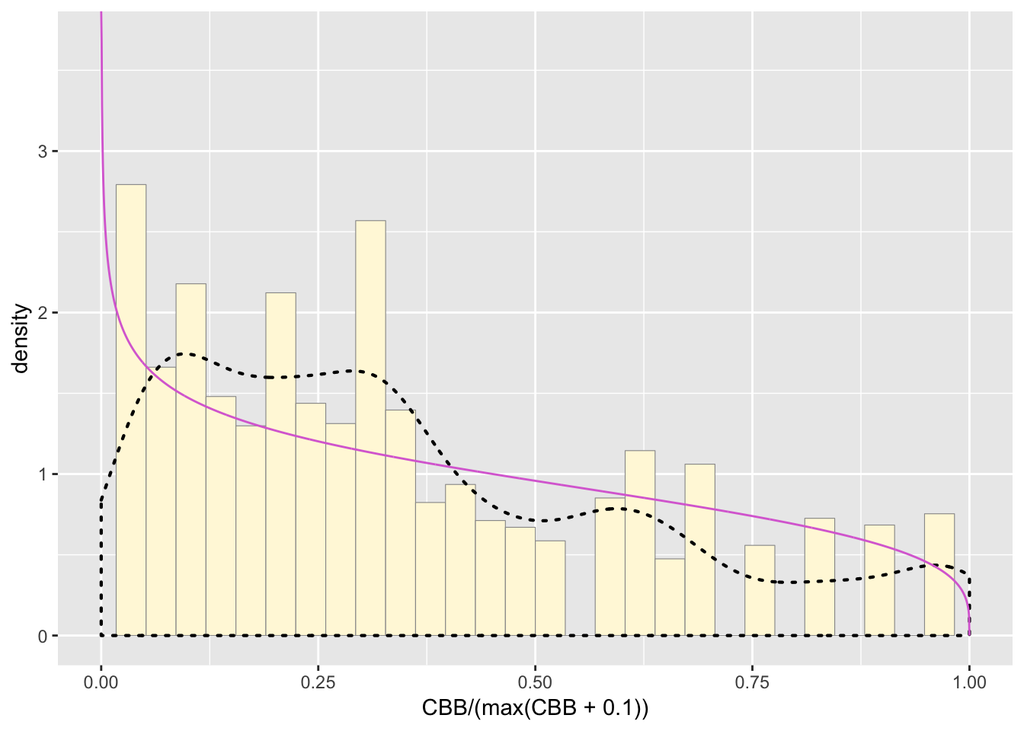

```r
pSpecial <- ggplot(data=z, aes(x=CBB/(max(CBB + 0.1)), y=..density..)) +
  geom_histogram(color="grey60",fill="cornsilk",size=0.2) +
  xlim(c(0,1)) +
  geom_density(size=0.75,linetype="dotted")

betaPars <- fitdistr(x=z$CBB/max(z$CBB + 0.1),start=list(shape1=1,shape2=2),"beta")
shape1ML <- betaPars$estimate["shape1"]
shape2ML <- betaPars$estimate["shape2"]

statSpecial <- stat_function(aes(x = xval, y = ..y..), fun = dbeta, colour="orchid", n = length(z$CBB), args = list(shape1=shape1ML,shape2=shape2ML))
pSpecial + statSpecial
```

Using the best-fitting distribution, go back to the code and get the maximum likelihood parameters. Use those to simulate a new data set, with the same length as your original vector.

```r
# random data based on the maximum likelihood parameters of my data.

r <- rnorm(n=2077,mean = 10.08137, sd = 7.4969)
r <- data.frame(1:2077,r)
names(r) <- list("id","x")
head(r)
```

```
##   id          x
## 1  1  7.0753007
## 2  2 15.5849710
## 3  3 -0.6150773
## 4  4 11.7892154
## 5  5 12.5560386
## 6  6  5.9360990
```

```r
str(r)
```

```
## 'data.frame':    2077 obs. of  2 variables:
##  $ id: int  1 2 3 4 5 6 7 8 9 10 ...
##  $ x : num  7.075 15.585 -0.615 11.789 12.556 ...
```

```r
summary(r$x)
```

```
##    Min. 1st Qu.  Median    Mean 3rd Qu.    Max.
## -12.494   5.072  10.192  10.127  15.001  34.380
```

Plot random data in a histogram and add the probability density curve.

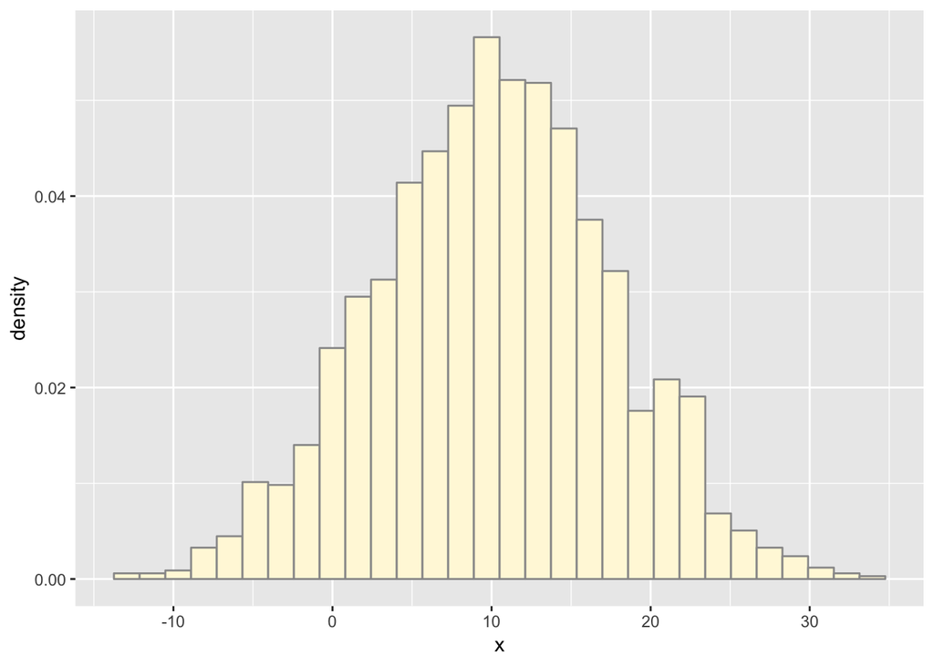

```r
# random histogram

r1 <- ggplot(data=r, aes(x=x, y=..density..)) +
  geom_histogram(color="grey60",fill="cornsilk",size=0.5)
print(r1)
```

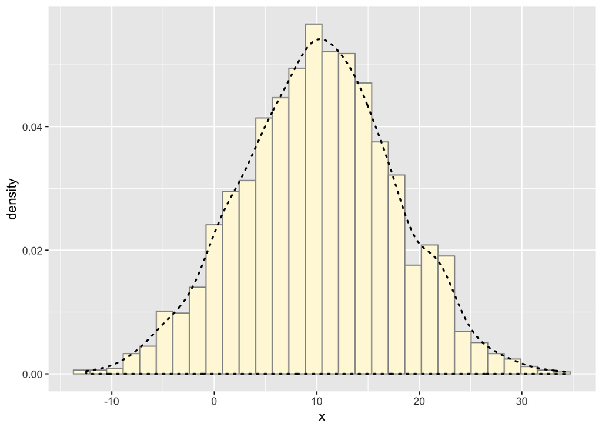

```r
# plot probability density curve

r1 <-  r1 +  geom_density(linetype="dotted",size=0.75)
print(r1)
```

```r
# get maximum likelihood parameters for normal
normPars <- fitdistr(r$x,"normal")
print(normPars)
```

```
##       mean          sd
##   10.1270253    7.4266826
##  ( 0.1629583) ( 0.1152290)
```

```r
str(normPars)
```

```
## List of 5
##  $ estimate: Named num [1:2] 10.13 7.43
##   ..- attr(*, "names")= chr [1:2] "mean" "sd"
##  $ sd      : Named num [1:2] 0.163 0.115
##   ..- attr(*, "names")= chr [1:2] "mean" "sd"
##  $ vcov    : num [1:2, 1:2] 0.0266 0 0 0.0133
##   ..- attr(*, "dimnames")=List of 2
##   .. ..$ : chr [1:2] "mean" "sd"
##   .. ..$ : chr [1:2] "mean" "sd"
##  $ n       : int 2077
##  $ loglik  : num -7112
##  - attr(*, "class")= chr "fitdistr"
```

```r
normPars$estimate["mean"]
```

```
##     mean
## 10.12703
```

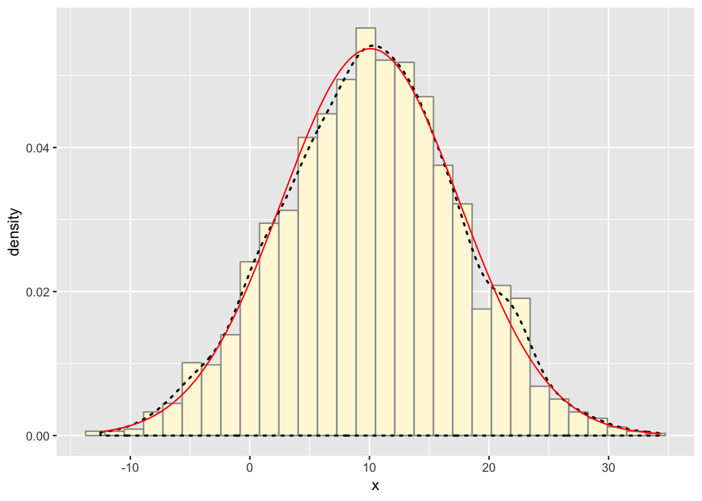

```r
# plot normal probability density
MeanML <- normPars$estimate["mean"]
sdML <- normPars$estimate["sd"]

xval <- seq(0,max(r$x),len=length(r$x))

stat <- stat_function(aes(x = xval, y = ..y..), fun = dnorm, colour="red", n = length(r$x), args = list(mean = meanML, sd = sdML))
r1 + stat
```

Generate a fresh histogram plot of the original data, and also include the probability density curve.

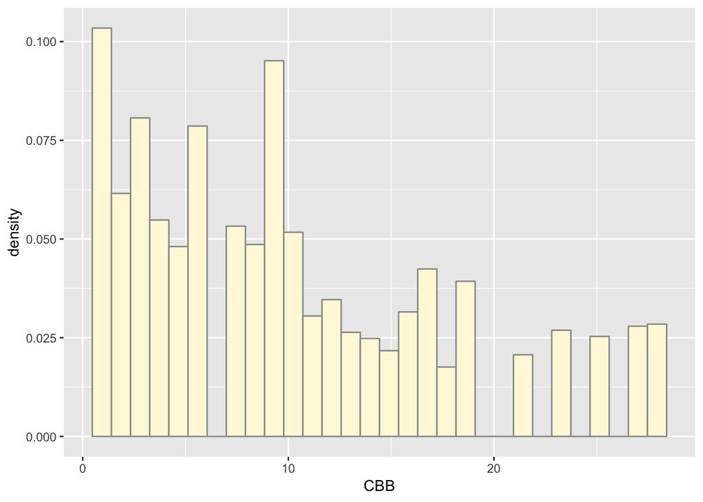

```r
# histogram of my data

p1 <- ggplot(data=z, aes(x=CBB, y=..density..)) +
  geom_histogram(color="grey60",fill="cornsilk",size=0.5)
print(p1)
```

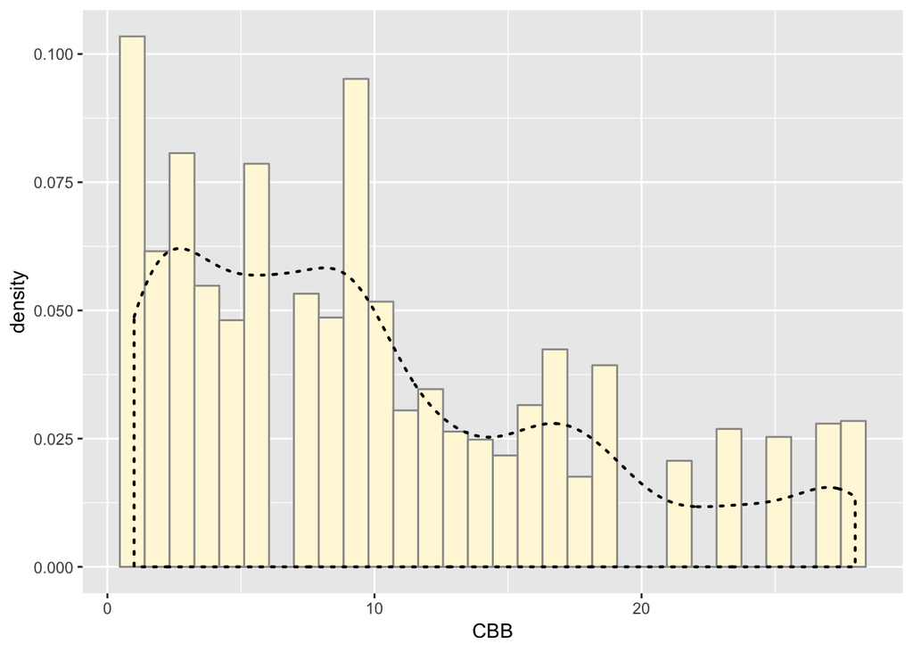

```r
# plot probability density curve

p1 <-  p1 +  geom_density(linetype="dotted",size=0.75)
print(p1)
```

```r
# get maximum likelihood parameters for normal
normPars <- fitdistr(z$CBB,"normal")
print(normPars)
```

```
##       mean          sd
##   10.0813674    7.4969180
##  ( 0.1644995) ( 0.1163187)
```

```r
str(normPars)
```

```
## List of 5
##  $ estimate: Named num [1:2] 10.1 7.5
##   ..- attr(*, "names")= chr [1:2] "mean" "sd"
##  $ sd      : Named num [1:2] 0.164 0.116
##   ..- attr(*, "names")= chr [1:2] "mean" "sd"
##  $ vcov    : num [1:2, 1:2] 0.0271 0 0 0.0135
##   ..- attr(*, "dimnames")=List of 2
##   .. ..$ : chr [1:2] "mean" "sd"
##   .. ..$ : chr [1:2] "mean" "sd"
##  $ n       : int 2077
##  $ loglik  : num -7131
##  - attr(*, "class")= chr "fitdistr"
```

```r
normPars$estimate["mean"]
```

```
##     mean
## 10.08137
```

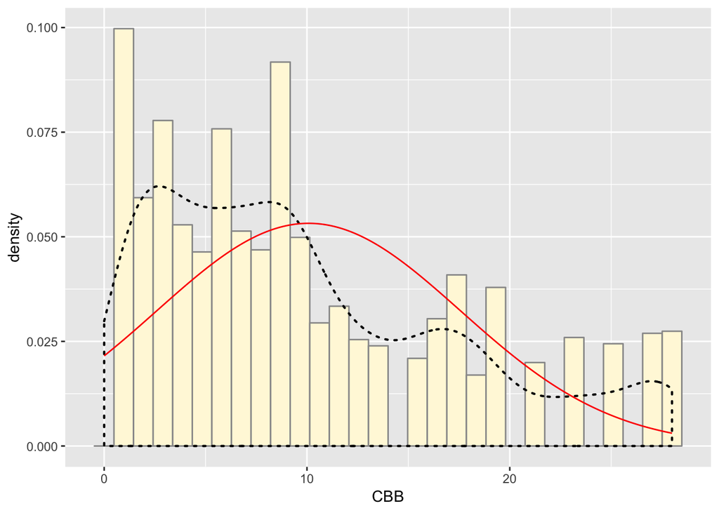

```r
# plot normal probability density
MeanML <- normPars$estimate["mean"]
sdML <- normPars$estimate["sd"]

xval <- seq(0,max(z$CBB),len=length(z$CBB))

stat <- stat_function(aes(x = xval, y = ..y..), fun = dnorm, colour="red", n = length(z$CBB), args = list(mean = meanML, sd = sdML))
p1 + stat
```

How do the two histogram profiles compare? Do you think the model is doing a good job of simulating realistic data that match your original measurements? Why or why not?

The two histograms are quite different. Even though the random data was created with same observation numbers, mean and standard deviation as my own data set, the distribution is still ideally normal as opposed to my dataset. In this case, it would seem the model is not doing a good job at matching original measurements because it’s adjusting too closely to the normal distribution.